# 基于scikit-learn的数据分析模型（1）- 回归分析

```python
import pandas as pd
import numpy as np
import matplotlib.pyplot as plt
plt.rcParams['font.sans-serif']=['SimHei']
plt.rcParams['axes.unicode_minus']=False
```

# 目录

## 上周作业

1. 求出31个省份2000-2019年每年的 住宅投资效率（单位：元/平方米）=住宅投资额（单位：亿元）/住宅投资面积（单位：万平方米）×10000。并将其以panel data的形式保存到excel中（index是DatetimeIndex类型，collumns是省份名字，值是所求的住宅投资效率值）
2. 选择合适的图形绘制北京、天津、上海、重庆四个直辖市的20年住宅投资效率的变化趋势对比图。
3. 文字简单描述2中图片可以得出的分析结果

### 评分点

1. 月数据处理成年数据
2. 计算公式不能错
3. 按要求保存到excel里
4. 选择合适的图形，要和分析结果相匹配
5. 分析要和图形相匹配

```python
invest=pd.read_excel('上周作业/各省月住宅投资额.xlsx',index_col=0)
area=pd.read_excel('上周作业/商品住宅施工面积.xlsx',index_col=0)
```

```python
type(invest.index)
```

```
pandas.core.indexes.base.Index
```

```python
type(area.index)
```

```
pandas.core.indexes.datetimes.DatetimeIndex
```

```python
len(area.index)==len(invest.index)
```

```
True
```

```python
invest.index=area.index
```

```python
invest.resample('YS').sum()
```

| 日期 | 北京市 | 天津市 | 河北省 | 山西省 | 内蒙古自治区 | 辽宁省 | 吉林省 | 黑龙江省 | 上海市 | 江苏省 | ... | 重庆市 | 四川省 | 贵州省 | 云南省 | 西藏自治区 | 陕西省 | 甘肃省 | 青海省 | 宁夏回族自治区 | 新疆维吾尔自治区 |
| --- | --- | --- | --- | --- | --- | --- | --- | --- | --- | --- | --- | --- | --- | --- | --- | --- | --- | --- | --- | --- | --- |
| 2000-01-01 | 288.26 | 113.85 | 70.57 | 25.01 | 28.82 | 180.60 | 45.89 | 71.28 | 398.96 | 260.57 | ... | 72.81 | 131.52 | 26.13 | 52.07 | 0.00 | 58.17 | 17.47 | 7.94 | 9.88 | 50.09 |
| 2001-01-01 | 464.22 | 120.50 | 82.89 | 31.63 | 40.02 | 228.46 | 74.90 | 101.63 | 472.38 | 314.10 | ... | 110.71 | 185.73 | 37.67 | 59.14 | 0.88 | 63.76 | 19.83 | 8.45 | 12.67 | 75.03 |
| 2002-01-01 | 586.74 | 120.79 | 104.88 | 36.93 | 39.51 | 276.15 | 82.05 | 77.12 | 555.60 | 396.83 | ... | 130.70 | 242.32 | 47.88 | 67.49 | 0.92 | 86.06 | 24.71 | 9.51 | 20.73 | 56.94 |
| 2003-01-01 | 632.97 | 153.29 | 167.86 | 49.13 | 51.55 | 343.27 | 95.97 | 88.59 | 676.28 | 596.08 | ... | 177.43 | 325.46 | 58.75 | 79.68 | 1.37 | 123.69 | 34.38 | 15.46 | 34.76 | 53.34 |
| 2004-01-01 | 775.99 | 175.24 | 223.53 | 72.15 | 68.84 | 480.60 | 112.72 | 139.73 | 900.67 | 960.94 | ... | 208.69 | 338.20 | 70.97 | 100.31 | 5.27 | 150.38 | 46.90 | 16.56 | 41.81 | 57.48 |
| 2005-01-01 | 779.53 | 234.93 | 292.69 | 115.43 | 114.65 | 614.11 | 144.69 | 174.84 | 920.84 | 1123.91 | ... | 300.37 | 471.83 | 84.09 | 167.13 | 3.72 | 211.05 | 60.31 | 16.52 | 47.45 | 69.52 |
| 2006-01-01 | 863.62 | 311.34 | 382.51 | 156.18 | 255.64 | 839.04 | 242.33 | 247.67 | 835.63 | 1419.90 | ... | 376.78 | 658.13 | 105.23 | 229.51 | 5.45 | 319.42 | 71.79 | 22.95 | 55.75 | 89.58 |
| 2007-01-01 | 991.66 | 342.82 | 572.32 | 190.25 | 383.92 | 1165.75 | 398.21 | 279.64 | 837.53 | 1879.19 | ... | 521.82 | 942.80 | 155.19 | 320.46 | 6.96 | 427.54 | 95.08 | 28.05 | 67.33 | 140.27 |
| 2008-01-01 | 940.56 | 459.33 | 847.18 | 227.94 | 572.09 | 1575.11 | 520.92 | 321.84 | 843.63 | 2296.62 | ... | 619.53 | 1021.94 | 194.05 | 423.64 | 10.99 | 586.64 | 124.19 | 42.70 | 87.56 | 186.77 |
| 2009-01-01 | 906.62 | 494.86 | 1218.32 | 379.46 | 573.82 | 1932.94 | 604.88 | 442.48 | 918.68 | 2424.15 | ... | 789.02 | 1149.17 | 248.01 | 552.96 | 11.37 | 782.33 | 137.32 | 55.47 | 126.08 | 184.09 |
| 2010-01-01 | 1508.95 | 565.39 | 1785.65 | 457.45 | 782.14 | 2481.10 | 731.82 | 656.93 | 1229.83 | 3159.94 | ... | 1091.49 | 1535.28 | 328.63 | 654.67 | 6.99 | 938.53 | 187.93 | 75.20 | 187.29 | 278.43 |
| 2011-01-01 | 1778.31 | 678.98 | 2296.31 | 615.03 | 1112.02 | 3413.44 | 903.60 | 938.82 | 1398.75 | 4085.85 | ... | 1438.45 | 1998.11 | 579.97 | 873.90 | 3.74 | 1180.11 | 258.06 | 90.20 | 235.80 | 417.93 |
| 2012-01-01 | 1627.99 | 843.05 | 2317.13 | 735.61 | 845.63 | 3961.95 | 987.74 | 1122.52 | 1451.94 | 4354.63 | ... | 1706.77 | 2197.75 | 930.31 | 1152.50 | 4.25 | 1477.57 | 412.51 | 141.10 | 279.49 | 444.27 |
| 2013-01-01 | 1724.56 | 986.28 | 2539.29 | 958.85 | 1003.57 | 4666.03 | 911.45 | 1124.72 | 1615.51 | 5171.50 | ... | 2044.24 | 2537.89 | 1224.23 | 1642.40 | 5.87 | 1768.95 | 539.85 | 159.72 | 340.27 | 555.62 |
| 2014-01-01 | 1846.08 | 1122.26 | 3010.35 | 1010.69 | 936.76 | 3844.26 | 732.47 | 946.03 | 1724.65 | 5924.51 | ... | 2451.37 | 2847.82 | 1350.34 | 1830.07 | 29.44 | 1869.69 | 496.37 | 190.67 | 411.58 | 616.30 |
| 2015-01-01 | 1889.54 | 1251.53 | 3162.55 | 1098.32 | 758.51 | 2603.32 | 648.81 | 681.15 | 1813.32 | 6080.21 | ... | 2390.49 | 3048.72 | 1327.77 | 1670.27 | 39.60 | 1827.80 | 526.56 | 201.38 | 396.68 | 603.66 |
| 2016-01-01 | 1925.86 | 1598.27 | 3475.48 | 1141.08 | 793.70 | 1505.42 | 710.69 | 597.96 | 1965.43 | 6628.87 | ... | 2319.97 | 3185.64 | 1243.60 | 1635.38 | 39.14 | 1916.13 | 563.75 | 227.78 | 435.41 | 518.83 |
| 2017-01-01 | 1694.67 | 1559.70 | 3656.98 | 846.38 | 645.85 | 1673.91 | 633.55 | 554.70 | 2152.40 | 7315.28 | ... | 2632.88 | 3182.34 | 1365.33 | 1743.91 | 20.10 | 2145.56 | 601.25 | 213.66 | 387.75 | 588.25 |
| 2018-01-01 | 2026.06 | 1863.50 | 3471.11 | 1033.76 | 641.99 | 1944.46 | 841.02 | 647.77 | 2225.92 | 8366.18 | ... | 3012.65 | 3764.71 | 1557.85 | 2115.17 | 49.99 | 2411.55 | 672.35 | 215.89 | 300.41 | 642.48 |
| 2019-01-01 | 2039.76 | 2200.01 | 3455.74 | 1296.48 | 782.13 | 2188.35 | 970.99 | 687.83 | 2318.13 | 9461.98 | ... | 3246.77 | 4665.31 | 2078.37 | 3028.96 | 96.87 | 2957.08 | 865.93 | 294.08 | 281.74 | 724.13 |
| 2020-01-01 | 0.00 | 0.00 | 0.00 | 0.00 | 0.00 | 0.00 | 0.00 | 0.00 | 0.00 | 0.00 | ... | 0.00 | 0.00 | 0.00 | 0.00 | 0.00 | 0.00 | 0.00 | 0.00 | 0.00 | 0.00 |

21 rows × 31 columns

```python
efficiency=((invest.resample('YS').sum()/area.resample('YS').sum())*10000)['2000':'2019']
```

```python
efficiency
```

| 日期 | 北京市 | 天津市 | 河北省 | 山西省 | 内蒙古自治区 | 辽宁省 | 吉林省 | 黑龙江省 | 上海市 | 江苏省 | ... | 重庆市 | 四川省 | 贵州省 | 云南省 | 西藏自治区 | 陕西省 | 甘肃省 | 青海省 | 宁夏回族自治区 | 新疆维吾尔自治区 |
| --- | --- | --- | --- | --- | --- | --- | --- | --- | --- | --- | --- | --- | --- | --- | --- | --- | --- | --- | --- | --- | --- |
| 2000-01-01 | 132.259814 | 96.233171 | 69.765810 | 80.601238 | 95.699817 | 114.613471 | 136.792748 | 110.461792 | 118.426696 | 105.139560 | ... | 56.205015 | 71.667205 | 60.497735 | 110.603444 | NaN | 85.948836 | 83.887542 | 76.360104 | 75.546720 | 133.389789 |
| 2001-01-01 | 147.599669 | 99.989047 | 70.966858 | 95.628539 | 97.192303 | 114.804482 | 122.039046 | 125.367140 | 124.551501 | 110.923707 | ... | 61.646418 | 76.293170 | 56.901604 | 108.122932 | 475.675676 | 76.853630 | 82.452537 | 71.646600 | 89.182645 | 106.294962 |
| 2002-01-01 | 141.852751 | 94.355467 | 86.705704 | 81.731567 | 95.651500 | 119.499827 | 81.847428 | 107.201786 | 115.648567 | 111.536242 | ... | 54.299665 | 77.259420 | 57.206351 | 105.448841 | 108.260767 | 91.051344 | 78.042094 | 54.429322 | 95.650288 | 87.054503 |
| 2003-01-01 | 130.184542 | 111.046638 | 99.474597 | 83.649737 | 107.584779 | 124.586611 | 149.851975 | 114.755075 | 115.398128 | 115.785192 | ... | 57.928855 | 75.318192 | 45.816004 | 92.084841 | 103.898074 | 105.541955 | 59.956367 | 73.759190 | 90.048314 | 81.750384 |
| 2004-01-01 | 140.170667 | 107.824473 | 108.377289 | 104.598568 | 108.834159 | 150.961603 | 153.994330 | 141.108204 | 132.607011 | 123.384442 | ... | 56.246535 | 72.786798 | 44.251540 | 87.695218 | 204.279402 | 97.482491 | 51.149389 | 71.080588 | 88.698711 | 103.378878 |
| 2005-01-01 | 134.217684 | 129.440156 | 126.166879 | 112.657609 | 112.044736 | 167.909356 | 166.266198 | 143.109831 | 126.665560 | 111.093835 | ... | 63.831533 | 85.951831 | 47.542049 | 89.106440 | 285.977860 | 110.053538 | 66.183450 | 68.408346 | 89.179828 | 108.735604 |
| 2006-01-01 | 155.325578 | 142.779705 | 123.640275 | 97.125416 | 131.286151 | 172.977466 | 178.130253 | 156.452340 | 114.898434 | 113.558850 | ... | 66.044053 | 90.529350 | 47.963653 | 102.575264 | 126.850386 | 144.815245 | 69.989315 | 82.699723 | 91.184018 | 116.059722 |
| 2007-01-01 | 190.833172 | 132.905899 | 147.263081 | 90.773413 | 131.421708 | 176.173886 | 180.210391 | 160.015473 | 115.304988 | 119.194116 | ... | 77.668764 | 99.836257 | 54.694574 | 120.984822 | 135.361158 | 150.733111 | 79.409026 | 70.278206 | 107.090597 | 123.519844 |
| 2008-01-01 | 187.805051 | 162.873218 | 155.309854 | 97.163693 | 143.308185 | 184.130659 | 201.450044 | 170.241217 | 132.799196 | 114.616244 | ... | 75.196676 | 83.786527 | 51.691212 | 116.593234 | 129.814904 | 151.500087 | 90.198904 | 91.957489 | 101.961323 | 118.979138 |
| 2009-01-01 | 178.624273 | 166.519113 | 149.063046 | 109.818617 | 117.746761 | 177.383515 | 206.730427 | 187.363071 | 151.950155 | 115.755773 | ... | 86.207433 | 87.472249 | 60.701604 | 126.230235 | 146.628322 | 142.980325 | 87.690898 | 94.416378 | 112.181498 | 105.673379 |
| 2010-01-01 | 287.345487 | 144.270750 | 125.135961 | 86.340497 | 135.423890 | 140.425432 | 148.119183 | 145.090013 | 182.769878 | 133.293435 | ... | 93.101011 | 102.368700 | 61.459690 | 112.444773 | 133.526906 | 124.318670 | 88.842014 | 70.731402 | 109.253438 | 118.847001 |
| 2011-01-01 | 279.650174 | 129.983850 | 121.872568 | 88.966237 | 136.821379 | 139.809386 | 150.103358 | 128.871997 | 179.328831 | 142.690360 | ... | 95.462769 | 102.337866 | 77.146619 | 130.315299 | 130.993660 | 123.636601 | 95.084010 | 69.583410 | 90.617931 | 125.094473 |
| 2012-01-01 | 228.260603 | 148.641501 | 111.439656 | 88.391185 | 84.348148 | 144.331120 | 141.016692 | 118.043895 | 171.102211 | 136.738026 | ... | 105.471508 | 100.345157 | 104.479838 | 125.970657 | 189.766030 | 126.756133 | 110.372134 | 104.225606 | 84.078181 | 90.556960 |
| 2013-01-01 | 247.730355 | 135.733342 | 111.451768 | 93.710046 | 84.694026 | 156.600406 | 105.413375 | 117.331997 | 198.591905 | 144.084366 | ... | 112.569732 | 115.649152 | 107.834340 | 136.956362 | 162.007010 | 127.982903 | 111.484827 | 99.423949 | 90.138417 | 94.333744 |
| 2014-01-01 | 264.591685 | 160.536371 | 133.243576 | 93.281419 | 77.494716 | 135.851467 | 87.569698 | 96.056030 | 207.142622 | 145.292777 | ... | 122.414203 | 123.453520 | 99.494247 | 139.515977 | 263.659893 | 126.480798 | 91.471162 | 115.949979 | 95.345430 | 87.049965 |
| 2015-01-01 | 302.859675 | 186.634515 | 141.971690 | 100.920377 | 65.258692 | 118.724968 | 79.370555 | 78.367535 | 221.406431 | 145.302903 | ... | 124.363865 | 122.837094 | 95.296169 | 120.214863 | 177.094840 | 119.341778 | 90.940633 | 130.106408 | 87.404714 | 86.850306 |
| 2016-01-01 | 328.301567 | 270.338842 | 151.360836 | 94.428130 | 69.614386 | 76.365253 | 85.572185 | 78.849698 | 243.379785 | 156.356913 | ... | 126.879676 | 123.836025 | 94.315339 | 121.106650 | 167.890601 | 120.011266 | 93.150009 | 136.605025 | 96.174405 | 72.896606 |
| 2017-01-01 | 324.418231 | 283.501201 | 162.468237 | 71.532864 | 58.266683 | 87.206690 | 74.529463 | 77.005634 | 268.735579 | 169.485816 | ... | 156.451292 | 124.253538 | 104.282349 | 127.546789 | 152.172432 | 125.848892 | 100.791412 | 123.783514 | 86.939715 | 84.238114 |
| 2018-01-01 | 354.141161 | 289.693668 | 170.064368 | 85.395118 | 64.043617 | 106.576407 | 100.893976 | 87.974576 | 297.980939 | 185.660101 | ... | 174.194924 | 142.795404 | 116.431223 | 156.884557 | 276.198527 | 142.842360 | 114.444618 | 134.115159 | 77.149746 | 95.984381 |
| 2019-01-01 | 346.920615 | 283.134246 | 160.910164 | 94.136044 | 76.545217 | 122.021293 | 115.295939 | 86.223733 | 319.562321 | 195.198926 | ... | 178.053160 | 153.483295 | 122.770449 | 187.995244 | 230.556124 | 153.363118 | 126.609485 | 163.918892 | 75.789306 | 95.140644 |

20 rows × 31 columns

```python
efficiency.to_excel('eff.xlsx')
```

```python
efficiency[['北京市','天津市','上海市','重庆市']]
```

| 日期 | 北京市 | 天津市 | 上海市 | 重庆市 |
| --- | --- | --- | --- | --- |
| 2000-01-01 | 132.259814 | 96.233171 | 118.426696 | 56.205015 |
| 2001-01-01 | 147.599669 | 99.989047 | 124.551501 | 61.646418 |
| 2002-01-01 | 141.852751 | 94.355467 | 115.648567 | 54.299665 |
| 2003-01-01 | 130.184542 | 111.046638 | 115.398128 | 57.928855 |
| 2004-01-01 | 140.170667 | 107.824473 | 132.607011 | 56.246535 |
| 2005-01-01 | 134.217684 | 129.440156 | 126.665560 | 63.831533 |
| 2006-01-01 | 155.325578 | 142.779705 | 114.898434 | 66.044053 |
| 2007-01-01 | 190.833172 | 132.905899 | 115.304988 | 77.668764 |
| 2008-01-01 | 187.805051 | 162.873218 | 132.799196 | 75.196676 |
| 2009-01-01 | 178.624273 | 166.519113 | 151.950155 | 86.207433 |
| 2010-01-01 | 287.345487 | 144.270750 | 182.769878 | 93.101011 |
| 2011-01-01 | 279.650174 | 129.983850 | 179.328831 | 95.462769 |
| 2012-01-01 | 228.260603 | 148.641501 | 171.102211 | 105.471508 |
| 2013-01-01 | 247.730355 | 135.733342 | 198.591905 | 112.569732 |
| 2014-01-01 | 264.591685 | 160.536371 | 207.142622 | 122.414203 |
| 2015-01-01 | 302.859675 | 186.634515 | 221.406431 | 124.363865 |
| 2016-01-01 | 328.301567 | 270.338842 | 243.379785 | 126.879676 |
| 2017-01-01 | 324.418231 | 283.501201 | 268.735579 | 156.451292 |
| 2018-01-01 | 354.141161 | 289.693668 | 297.980939 | 174.194924 |
| 2019-01-01 | 346.920615 | 283.134246 | 319.562321 | 178.053160 |

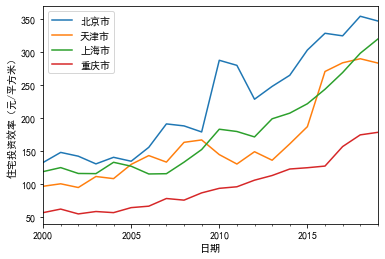

```python
fig,ax=plt.subplots()
efficiency[['北京市','天津市','上海市','重庆市']].plot(ax=ax)
ax.set_ylabel('住宅投资效率（元/平方米）')
```

## scikit-learn简介

scikit-learn 是基于 Python 语言的**机器学习**工具

官方网址https://scikit-learn.org/stable/

官方文档的中文翻译https://sklearn.apachecn.org/ 中文翻译的版本旧一些，想锻炼英语的同学建议读原版。

**scikit-learn的安装和调用**

anaconda自带，非anaconda环境可以使用pip安装`pip install -U scikit-learn`

调用常用的形式为`from sklearn import 包中的功能`

**scikit-learn的主要功能(其主页展示的功能):**

[figure not shown]

咱们主要掌握前三个数据分析的方法：

1. 分类分析（Classification）
2. 回归分析（Regression）
3. 聚类分析（Clustering）

## 最小二乘法线性回归

**线性回归**`sklearn.linear_model.LinearRegression`

目标值 y 是输入变量 x 的线性组合。 数学概念表示为：如果$\hat{y}$ 是预测值，那么有：

$\hat{y}(w, x) = w_0 + w_1 x_1 + ... + w_p x_p$

在整个模块中，我们定义向量 $w = (w_1,..., w_p)$ 作为 $coef_$ ，定义 $w_0$ 作为 $intercept_$ 。

**最小二乘法（Ordinary Least Squares，OLS）**

线性回归拟合一个带有系数 $w = (w_1, ..., w_p)$ 的线性模型，使得数据集实际观测数据和预测数据（估计值）之间的残差平方和最小。其数学表达式为:

$$\min_{w} || X w - y||_2^2$$

**scikit-learn实现**

LinearRegression 会调用 $fit$ 方法来拟合数组 $X， y$ 并且将线性模型的系数 $w$ 存储在其成员变量 $coef_$ 中:

[figure not shown]

### 例子1：单变量线性回归

```python
from sklearn import linear_model as lm
```

由于scikit-leaen这个包中的功能很多，我们可以只调用我们分析时要使用的那部分功能，可以减少代码量

```python
reg = lm.LinearRegression()  #构建一个线性回归对象
type(reg)
```

```
sklearn.linear_model._base.LinearRegression
```

构建一组用于回归的数据

```python
x = np.arange(16).reshape(-1,1)
```

```python
x
```

```
array([[ 0],
       [ 1],
       [ 2],
       [ 3],
       [ 4],
       [ 5],
       [ 6],
       [ 7],
       [ 8],
       [ 9],
       [10],
       [11],
       [12],
       [13],
       [14],
       [15]])
```

```python
y = x*3+3
y
```

```
array([[ 3],
       [ 6],
       [ 9],
       [12],
       [15],
       [18],
       [21],
       [24],
       [27],
       [30],
       [33],
       [36],
       [39],
       [42],
       [45],
       [48]])
```

```python
reg.fit(x,y)
```

```
LinearRegression()
```

```python
print('系数为：',reg.coef_,'\n截距为：',reg.intercept_)
```

```
系数为： [[3.]]
截距为： [3.]
```

### 例子2：北京市2000-2015年GDP和人口的关系

```python
beijing=pd.read_excel('北京GDP和人口.xlsx',index_col=0)
beijing
```

|  | GDP | POP |
| --- | --- | --- |
| 2015年 | 23014.59 | 2171 |
| 2014年 | 21330.83 | 2152 |
| 2013年 | 19800.81 | 2115 |
| 2012年 | 17879.40 | 2069 |
| 2011年 | 16251.93 | 2019 |
| 2010年 | 14113.58 | 1962 |
| 2009年 | 12153.03 | 1860 |
| 2008年 | 11115.00 | 1771 |
| 2007年 | 9846.81 | 1676 |
| 2006年 | 8117.78 | 1601 |
| 2005年 | 6969.52 | 1538 |
| 2004年 | 6033.21 | 1493 |
| 2003年 | 5007.21 | 1456 |
| 2002年 | 4315.00 | 1423 |
| 2001年 | 3707.96 | 1385 |
| 2000年 | 3161.66 | 1364 |

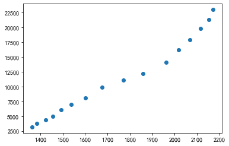

```python
fig,ax=plt.subplots()
ax.scatter(beijing['POP'],beijing['GDP'])
```

看图发现随着人口增加，GDP是增长的。

我们**假设**GDP是人口的线性函数，即 $$H: GDP=a\times POP+b$$ 我们使用上述的最小二乘法线性回归

```python
reg_pop_to_gdp = lm.LinearRegression()
```

将数据转换成fit接收的数据

```python
beijing['POP']
```

```
2015年    2171
2014年    2152
2013年    2115
2012年    2069
2011年    2019
2010年    1962
2009年    1860
2008年    1771
2007年    1676
2006年    1601
2005年    1538
2004年    1493
2003年    1456
2002年    1423
2001年    1385
2000年    1364
Name: POP, dtype: int64
```

```python
beijing['POP'].values
```

```
array([2171, 2152, 2115, 2069, 2019, 1962, 1860, 1771, 1676, 1601, 1538,
       1493, 1456, 1423, 1385, 1364], dtype=int64)
```

```python
beijing['POP'].values.reshape(-1,1)
```

```
array([[2171],
       [2152],
       [2115],
       [2069],
       [2019],
       [1962],
       [1860],
       [1771],
       [1676],
       [1601],
       [1538],
       [1493],
       [1456],
       [1423],
       [1385],
       [1364]], dtype=int64)
```

```python
x=beijing['POP'].values.reshape(-1,1)
y=beijing['GDP'].values.reshape(-1,1)
x
```

```
array([[2171],
       [2152],
       [2115],
       [2069],
       [2019],
       [1962],
       [1860],
       [1771],
       [1676],
       [1601],
       [1538],
       [1493],
       [1456],
       [1423],
       [1385],
       [1364]], dtype=int64)
```

```python
reg_pop_to_gdp.fit(x,y)
```

```
LinearRegression()
```

```python
print('系数为：',reg_pop_to_gdp.coef_,'\n截距为：',reg_pop_to_gdp.intercept_)
```

```
系数为： [[22.06604839]]
截距为： [-27265.29171652]
```

把拟合结果画在图上

```python
y_hat=x*reg_pop_to_gdp.coef_+reg_pop_to_gdp.intercept_
y_hat
```

```
array([[20640.09932911],
       [20220.84440977],
       [19404.4006195 ],
       [18389.36239375],
       [17286.05997446],
       [16028.29521647],
       [13777.55828111],
       [11813.67997478],
       [ 9717.40537812],
       [ 8062.45174919],
       [ 6672.29070088],
       [ 5679.31852352],
       [ 4862.87473324],
       [ 4134.69513651],
       [ 3296.18529785],
       [ 2832.79828175]])
```

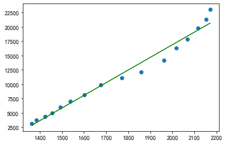

```python
ax.plot(x,y_hat,color='green')
fig
```

那么如果人口达到了3000万或者3500万，GDP会是多少？

可以使用predit功能实现

```python
reg_pop_to_gdp.predict([[3000],[3500]]) #注意在输入自变量时，要以二维数组的形式，即两层中括号嵌套
```

```
array([[38932.85344095],
       [49965.87763386]])
```

即北京人口3000万，那么GDP会达到38932.85344095亿元；人口达到3500万，GDP会达到49965.87763386亿元

真实数据：

|  | 2019 | 2018 | 2017 | 2016 |
| --- | --- | --- | --- | --- |
| 人口 | 2154 | 2154 | 2171 | 2173 |
| GDP | 35445.1 | 33106.0 | 29883.0 | 27041.2 |

### 例子3：多元线性回归

```python
X = np.array([[1, 1], [1, 2], [2, 2], [2, 3]])
# y = 1 * x_0 + 2 * x_1 + 3
y = np.dot(X, np.array([1, 2])) + 3
print(y)
```

```
[ 6  8  9 11]
```

```python
reg = lm.LinearRegression().fit(X, y)
print("系数：",reg.coef_,"\n截距：",reg.intercept_)
```

```
系数： [1. 2.]
截距： 3.0000000000000018
```

### 例子4：华北地区其他省份GDP对北京GDP的影响

```python
northchina_gdp=pd.read_excel('华北地区各省GDP.xlsx',index_col=0)
northchina_gdp
```

| 地区 | 北京市 | 天津市 | 河北省 | 山西省 | 内蒙古自治区 |
| --- | --- | --- | --- | --- | --- |
| 2018年 | 30319.98 | 18809.64 | 36010.27 | 16818.11 | 17289.22 |
| 2017年 | 28014.94 | 18549.19 | 34016.32 | 15528.42 | 16096.21 |
| 2016年 | 25669.13 | 17885.39 | 32070.45 | 13050.41 | 18128.10 |
| 2015年 | 23014.59 | 16538.19 | 29806.11 | 12766.49 | 17831.51 |
| 2014年 | 21330.83 | 15726.93 | 29421.15 | 12761.49 | 17770.19 |
| 2013年 | 19800.81 | 14442.01 | 28442.95 | 12665.25 | 16916.50 |
| 2012年 | 17879.40 | 12893.88 | 26575.01 | 12112.83 | 15880.58 |
| 2011年 | 16251.93 | 11307.28 | 24515.76 | 11237.55 | 14359.88 |
| 2010年 | 14113.58 | 9224.46 | 20394.26 | 9200.86 | 11672.00 |
| 2009年 | 12153.03 | 7521.85 | 17235.48 | 7358.31 | 9740.25 |
| 2008年 | 11115.00 | 6719.01 | 16011.97 | 7315.40 | 8496.20 |
| 2007年 | 9846.81 | 5252.76 | 13607.32 | 6024.45 | 6423.18 |
| 2006年 | 8117.78 | 4462.74 | 11467.60 | 4878.61 | 4944.25 |
| 2005年 | 6969.52 | 3905.64 | 10012.11 | 4230.53 | 3905.03 |
| 2004年 | 6033.21 | 3110.97 | 8477.63 | 3571.37 | 3041.07 |
| 2003年 | 5007.21 | 2578.03 | 6921.29 | 2855.23 | 2388.38 |
| 2002年 | 4315.00 | 2150.76 | 6018.28 | 2324.80 | 1940.94 |
| 2001年 | 3707.96 | 1919.09 | 5516.76 | 2029.53 | 1713.81 |
| 2000年 | 3161.66 | 1701.88 | 5043.96 | 1845.72 | 1539.12 |
| 1999年 | 2678.82 | 1500.95 | 4514.19 | 1667.10 | 1379.31 |
| 1998年 | 2377.18 | 1374.60 | 4256.01 | 1611.08 | 1262.54 |
| 1997年 | 2077.09 | 1264.63 | 3953.78 | 1476.00 | 1153.51 |
| 1996年 | 1789.20 | 1121.93 | 3452.97 | 1292.11 | 1023.09 |
| 1995年 | 1507.69 | 931.97 | 2849.52 | 1076.03 | 857.06 |
| 1994年 | 1145.31 | 732.89 | 2187.49 | 826.66 | 695.06 |
| 1993年 | 886.21 | 538.94 | 1690.84 | 680.41 | 537.81 |

我们提出**假设**北京的GDP受其他华北地区省份GDP的影响 $$H: GDP_{bj}=w_1\times GDP_{tj}+w_2\times GDP_{hb}+w_3\times GDP_{sx}+w_4\times GDP_{nm}+b$$ 我们使用上述的最小二乘法线性回归

首先把数据转成scikit-learn能接受的类型，即自变量们构成一个N行X列的二维数组，每一列是一个变量，每一行是一组观测样本。因变量构成一个N行1列的数组。

```python
X=northchina_gdp[['天津市', '河北省', '山西省', '内蒙古自治区']].values
y=northchina_gdp[['北京市']].values
```

```python
X
```

```
array([[18809.64, 36010.27, 16818.11, 17289.22],
       [18549.19, 34016.32, 15528.42, 16096.21],
       [17885.39, 32070.45, 13050.41, 18128.1 ],
       [16538.19, 29806.11, 12766.49, 17831.51],
       [15726.93, 29421.15, 12761.49, 17770.19],
       [14442.01, 28442.95, 12665.25, 16916.5 ],
       [12893.88, 26575.01, 12112.83, 15880.58],
       [11307.28, 24515.76, 11237.55, 14359.88],
       [ 9224.46, 20394.26,  9200.86, 11672.  ],
       [ 7521.85, 17235.48,  7358.31,  9740.25],
       [ 6719.01, 16011.97,  7315.4 ,  8496.2 ],
       [ 5252.76, 13607.32,  6024.45,  6423.18],
       [ 4462.74, 11467.6 ,  4878.61,  4944.25],
       [ 3905.64, 10012.11,  4230.53,  3905.03],
       [ 3110.97,  8477.63,  3571.37,  3041.07],
       [ 2578.03,  6921.29,  2855.23,  2388.38],
       [ 2150.76,  6018.28,  2324.8 ,  1940.94],
       [ 1919.09,  5516.76,  2029.53,  1713.81],
       [ 1701.88,  5043.96,  1845.72,  1539.12],
       [ 1500.95,  4514.19,  1667.1 ,  1379.31],
       [ 1374.6 ,  4256.01,  1611.08,  1262.54],
       [ 1264.63,  3953.78,  1476.  ,  1153.51],
       [ 1121.93,  3452.97,  1292.11,  1023.09],
       [  931.97,  2849.52,  1076.03,   857.06],
       [  732.89,  2187.49,   826.66,   695.06],
       [  538.94,  1690.84,   680.41,   537.81]])
```

```python
y
```

```
array([[30319.98],
       [28014.94],
       [25669.13],
       [23014.59],
       [21330.83],
       [19800.81],
       [17879.4 ],
       [16251.93],
       [14113.58],
       [12153.03],
       [11115.  ],
       [ 9846.81],
       [ 8117.78],
       [ 6969.52],
       [ 6033.21],
       [ 5007.21],
       [ 4315.  ],
       [ 3707.96],
       [ 3161.66],
       [ 2678.82],
       [ 2377.18],
       [ 2077.09],
       [ 1789.2 ],
       [ 1507.69],
       [ 1145.31],
       [  886.21]])
```

可以先画图观察每个自变量与因变量之间的相关性

```python
northchina_gdp.columns.values[1]
```

```
'天津市'
```

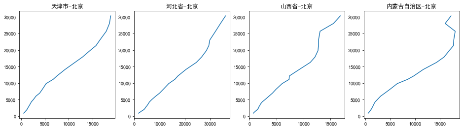

```python
fig_nc,ax_nc=plt.subplots(1,4,figsize=(16,4))
for i in range(4):
    ax_nc[i].plot(X.T[i],y.T[0])
    ax_nc[i].set_title(northchina_gdp.columns.values[i+1]+'-北京')
```

```python
reg_northchina = lm.LinearRegression().fit(X, y)
```

```python
print("系数：",reg_northchina.coef_,"\n截距：",reg_northchina.intercept_)
```

```
系数： [[ 0.7103604   1.04157113 -0.3668073  -0.8123149 ]]
截距： [-1124.07950547]
```

```python
y_hat=np.dot(X,reg_northchina.coef_.reshape(4,1))+reg_northchina.intercept_
```

```
[2018 2017 2016 2015 2014 2013 2012 2011 2010 2009 2008 2007 2006 2005
 2004 2003 2002 2001 2000 1999 1998 1997 1996 1995 1994 1993]
```

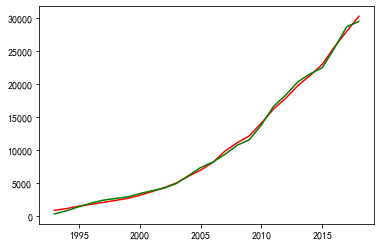

```python
year=np.arange(2018,1992,-1)
print(year)
fig1,ax1=plt.subplots()
ax1.plot(year,y,c='red')
ax1.plot(year,y_hat,c='green')
```

## 机器学习模型评价

通过机器学习做出回归模型后，一个重要的用途是用来做预测。那么模型的预测能力就需要做出评估。

比如我们想要评估例子4中模型的预测能力，可以把1993-2018年的数据分为2部分，一部分用来学习，一部分用来检验学习成果。

以下我们取1993-2012，20年的数据用来学习，2013-2018 6年的数据用来检验。

```python
X_study=X[6:]
y_study=y[6:]
X_test=X[0:6]
y_test=y[0:6]
```

```python
reg_study=lm.LinearRegression().fit(X_study, y_study)
```

```python
y_predict=reg_study.predict(X_test)
```

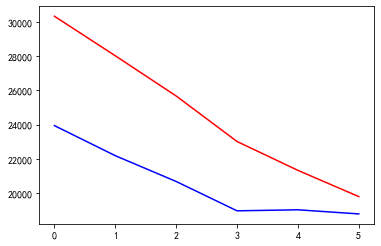

```python
fig3,ax3=plt.subplots()
ax3.plot(y_test,c='r')
ax3.plot(y_predict,c='b')
```

可以看到，基于1993-2012这20年的数据学习来的模型，预测的结果偏低。

**sci-kit learn这个包提供了一个score功能，用来给模型打分**

返回的是$R^2 =(1 - u/v)$, 其中 `u=((y_true - y_pred) ** 2).sum()` ,`v=((y_true - y_true.mean()) ** 2).sum()` 取值区间为$(-\infty,1.0]$

[figure not shown]

```python
reg_study.score(X_test,y_test)
```

```
-0.495517216037471
```

```python
reg_study.score(X_study,y_study)
```

```
0.9979173785884633
```

可见这个模型预测的准确性很差，说明（1）这个模型不合适（2）在2012年之后GDP变化规律发生了重大变化

过度拟合：学习数据拟合程度很高，预测数据拟合程度很低

## 实例

```python
data=pd.read_excel('全国GDP和居民消费水平.xlsx',index_col=0)
data
```

|  | GDP | 居民消费水平 |
| --- | --- | --- |
| 2018年 | 915887.3 | 25378 |
| 2017年 | 831381.2 | 23070 |
| 2016年 | 743408.3 | 20877 |
| 2015年 | 686255.7 | 18929 |
| 2014年 | 644380.2 | 17271 |
| 2013年 | 588141.2 | 15615 |
| 2012年 | 537329.0 | 14075 |
| 2011年 | 483392.8 | 12646 |
| 2010年 | 410354.1 | 10550 |
| 2009年 | 347934.9 | 9226 |
| 2008年 | 321229.5 | 8483 |
| 2007年 | 270704.0 | 7434 |
| 2006年 | 219028.5 | 6302 |
| 2005年 | 185998.9 | 5671 |
| 2004年 | 161415.4 | 5056 |
| 2003年 | 136576.3 | 4542 |
| 2002年 | 120480.4 | 4256 |
| 2001年 | 109276.2 | 3954 |
| 2000年 | 99066.1 | 3698 |
| 1999年 | 89366.5 | 3327 |
| 1998年 | 83817.6 | 3107 |
| 1997年 | 78802.9 | 2959 |
| 1996年 | 70779.6 | 2749 |
| 1995年 | 60356.6 | 2317 |
| 1994年 | 48548.2 | 1789 |
| 1993年 | 35599.2 | 1324 |
| 1992年 | 27208.2 | 1051 |
| 1991年 | 22050.3 | 910 |
| 1990年 | 18923.3 | 825 |
| 1989年 | 17188.4 | 779 |
| 1988年 | 15174.4 | 678 |
| 1987年 | 12166.6 | 553 |
| 1986年 | 10375.4 | 492 |
| 1985年 | 9123.6 | 437 |
| 1984年 | 7314.2 | 354 |
| 1983年 | 6043.8 | 313 |
| 1982年 | 5380.5 | 282 |
| 1981年 | 4933.7 | 263 |
| 1980年 | 4587.6 | 237 |

```python
X_study=data['GDP'].values[4:].reshape(-1, 1)
y_study=data['居民消费水平'].values[4:].reshape(-1, 1)
X_test=data['GDP'].values[0:4].reshape(-1, 1)
y_test=data['居民消费水平'].values[0:4].reshape(-1, 1)
```

```python
reg_ti_gdp=lm.LinearRegression().fit(X_study, y_study)
y_predict=reg_ti_gdp.predict(X_test)
```

```python
reg_ti_gdp.score(X_test,y_test)
```

```
0.7682192957295395
```

预测效果不错

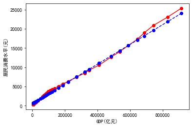

```python
fig3,ax3=plt.subplots()
ax3.plot(data['GDP'],data['居民消费水平'],'r-o')
ax3.plot(data['GDP'],reg_ti_gdp.predict(data['GDP'].values.reshape(-1, 1)),'b--o')
ax3.set_xlabel('GDP(亿元)')
ax3.set_ylabel('居民消费水平(元)')
```

## 参考资料

1. 想自学计量经济学的同学可以看这个公开课：清华大学李子奈老师http://m.v.dxsbb.com/jingguan/1726/
2. scikit-learn中支持其他的常见的计量分析模型

| **模块名称** | **函数名称** | **算法名称** |
| --- | --- | --- |
| linear_model | LinearRegression | 线性回归 |
| svm | SVR | 支持向量回归 |
| neighbors | KNeighborsRegressor | 最近邻回归 |
| tree | DecisionTreeRegressor | 回归决策树 |
| ensemble | RandomForestRegressor | 随机森林回归 |
| ensemble | GradientBoostingRegressor | 梯度提升回归树 |

## 作业

使用**青春有你3.xlsx**选手数据（来源：百度百科，https://baike.baidu.com/item/%E9%9D%92%E6%98%A5%E6%9C%89%E4%BD%A0%E7%AC%AC%E4%B8%89%E5%AD%A3/51140980?fromtitle=%E9%9D%92%E6%98%A5%E6%9C%89%E4%BD%A03&fromid=51144702&fr=aladdin）， 完成以下分析：

1. 构建线性回归模型，自变量为选手身高，因变量为选手体重。得出拟合结果：体重=a$\times$身高+b
2. 在同一幅图中画出选手的身高（纵轴）、体重（横轴）散点图，和1中的拟合直线线：体重=a$\times$身高+b。

作业提交jupyter notebook，内含代码和图片。不用提交原始数据。

邮件主题：python-作业4-姓名

notebook命名：作业4-姓名-学号